# Practical Machine Learning Course Project

Adraine Upshaw

October 29, 2016

## Synopsis:

Using devices such as Jawbone Up, Nike FuelBand, and Fitbit it is now possible to collect a large amount of data about personal activity relatively inexpensively. These type of devices are part of the quantified self movement - a group of enthusiasts who take measurements about themselves regularly to improve their health, to find patterns in their behavior, or because they are tech geeks. One thing that people regularly do is quantify how much of a particular activity they do, but they rarely quantify how well they do it. In this project, I will use data from accelerometers on the belt, forearm, arm, and dumbell of 6 participants. Participants were asked to perform barbell lifts correctly and incorrectly in 5 different ways(classe variable). The project will outline the steps used to develop a prediction model for the 5 different ways. More information is available from the website here: http://groupware.les.inf.puc-rio.br/har (see the section on the Weight Lifting Exercise Dataset).

## Data Processing (loading and preprocessing the data):

```r
options(scipen = 2, digits = 0)
setwd("~/DataScience/Pratical Machine Learning")
#setwd("H:/DataScientist/practical-machine-learning")
library(caret); library(rattle); library(rpart); library(rpart.plot)
library(randomForest);library(gbm);library(ggplot2)
library(plyr);library(knitr)
if(!file.exists("./data")){dir.create("./data")}
fileUrl <- "https://d396qusza40orc.cloudfront.net/predmachlearn/pml-training.csv"
if (!file.exists("./data/pml-training.csv")) {download.file(fileUrl, destfile ="./data/pml-training.csv")
}
training <- read.csv("./data/pml-training.csv", header = TRUE,
                         na.strings = c("","NA","#DIV/0!"))

fileUrl2 <- "https://d396qusza40orc.cloudfront.net/predmachlearn/pml-testing.csv"
if (!file.exists("./data/pml-testing.csv")) {download.file(fileUrl2, destfile ="./data/pml-testing.csv")
}
testing <- read.csv("./data/pml-testing.csv", header = TRUE,
                    na.strings = c("","NA","#DIV/0!"))
str(training)
```

```
## 'data.frame':    19622 obs. of  160 variables:
##  $ X                       : int  1 2 3 4 5 6 7 8 9 10 ...
##  $ user_name               : Factor w/ 6 levels "adelmo","carlitos",..: 2 2 2 2 2 2 2 2 2 2 ...
##  $ raw_timestamp_part_1    : int  1323084231 1323084231 1323084231 1323084232 1323084232 1323084232 1323084232 1323084232 1323084232 1323084232 ...
##  $ raw_timestamp_part_2    : int  788290 808298 820366 120339 196328 304277 368296 440390 484323 484434 ...
##  $ cvtd_timestamp          : Factor w/ 20 levels "02/12/2011 13:32",..: 9 9 9 9 9 9 9 9 9 9 ...
##  $ new_window              : Factor w/ 2 levels "no","yes": 1 1 1 1 1 1 1 1 1 1 ...
##  $ num_window              : int  11 11 11 12 12 12 12 12 12 12 ...
##  $ roll_belt               : num  1.41 1.41 1.42 1.48 1.48 1.45 1.42 1.42 1.43 1.45 ...
##  $ pitch_belt              : num  8.07 8.07 8.07 8.05 8.07 8.06 8.09 8.13 8.16 8.17 ...
##  $ yaw_belt                : num  -94.4 -94.4 -94.4 -94.4 -94.4 -94.4 -94.4 -94.4 -94.4 -94.4 ...
##  $ total_accel_belt        : int  3 3 3 3 3 3 3 3 3 3 ...
##  $ kurtosis_roll_belt      : num  NA NA NA NA NA NA NA NA NA NA ...
##  $ kurtosis_picth_belt     : num  NA NA NA NA NA NA NA NA NA NA ...
##  $ kurtosis_yaw_belt       : logi  NA NA NA NA NA NA ...
```

[output cut: 86 more lines]

```r
summary(training)
```

[output not shown]

[output cut: 281 more lines]

[output not shown]

Variables that are mosting missing and near zero variance are removed, along with several id-type variable. Data will be split into training and validation data frames for model building and evaluation

```r
#remove X variable and other ID variables
training2 <- training[,-c(1:7)]
ncol(training);ncol(training2)
```

```
## [1] 160
```

```
## [1] 153
```

```r
#remove columns with more than 50% NA values
training3=training2[, colSums(is.na(training2)) <= nrow(training2) * 0.5]
ncol(training2);ncol(training3)
```

```
## [1] 153
```

```
## [1] 53
```

```r
#remove columns with zero variance
nzv <-nearZeroVar(training3, saveMetrics= TRUE)
training4 <- training3[, nzv$nzv==FALSE]
ncol(training3);ncol(training4)
```

```
## [1] 53
```

```
## [1] 52
```

```r
str(training4)
```

```
## 'data.frame':    19622 obs. of  52 variables:
##  $ roll_belt           : num  1.41 1.41 1.42 1.48 1.48 1.45 1.42 1.42 1.43 1.45 ...
##  $ pitch_belt          : num  8.07 8.07 8.07 8.05 8.07 8.06 8.09 8.13 8.16 8.17 ...
##  $ yaw_belt            : num  -94.4 -94.4 -94.4 -94.4 -94.4 -94.4 -94.4 -94.4 -94.4 -94.4 ...
##  $ total_accel_belt    : int  3 3 3 3 3 3 3 3 3 3 ...
##  $ gyros_belt_x        : num  0 0.02 0 0.02 0.02 0.02 0.02 0.02 0.02 0.03 ...
##  $ gyros_belt_y        : num  0 0 0 0 0.02 0 0 0 0 0 ...
##  $ gyros_belt_z        : num  -0.02 -0.02 -0.02 -0.03 -0.02 -0.02 -0.02 -0.02 -0.02 0 ...
##  $ accel_belt_x        : int  -21 -22 -20 -22 -21 -21 -22 -22 -20 -21 ...
##  $ accel_belt_y        : int  4 4 5 3 2 4 3 4 2 4 ...
##  $ accel_belt_z        : int  22 22 23 21 24 21 21 21 24 22 ...
##  $ magnet_belt_x       : int  -3 -7 -2 -6 -6 0 -4 -2 1 -3 ...
##  $ magnet_belt_y       : int  599 608 600 604 600 603 599 603 602 609 ...
##  $ magnet_belt_z       : int  -313 -311 -305 -310 -302 -312 -311 -313 -312 -308 ...
##  $ roll_arm            : num  -128 -128 -128 -128 -128 -128 -128 -128 -128 -128 ...
```

[output cut: 38 more lines]

```r
#create validation set
set.seed(67915)
inTrain = createDataPartition(training4$classe, p = 3/4)[[1]]
training5 = training4[ inTrain,]
validation = training4[-inTrain,]
```

## Model Selection

Three model prediction methods will be compared: Decision Tree, Random Forest, and Boosting

```r
#Decision Tree
model1 <- train(classe~., data=training5, method="rpart")
varImp_tree <- varImp(model1)
varImp_tree
```

```
## rpart variable importance
##
##   only 20 most important variables shown (out of 51)
##
##                   Overall
## pitch_forearm       100.0
## roll_forearm         72.6
## roll_belt            72.5
## magnet_dumbbell_y    49.2
## accel_belt_z         44.5
## magnet_belt_y        42.7
## yaw_belt             42.1
## total_accel_belt     36.5
## magnet_arm_x         27.5
## accel_arm_x          26.4
## roll_dumbbell        19.0
## magnet_dumbbell_z    18.7
## magnet_dumbbell_x    18.0
## accel_dumbbell_y     16.3
## roll_arm             15.9
## gyros_belt_z          0.0
## gyros_belt_x          0.0
## accel_dumbbell_z      0.0
## magnet_belt_x         0.0
## total_accel_arm       0.0
```

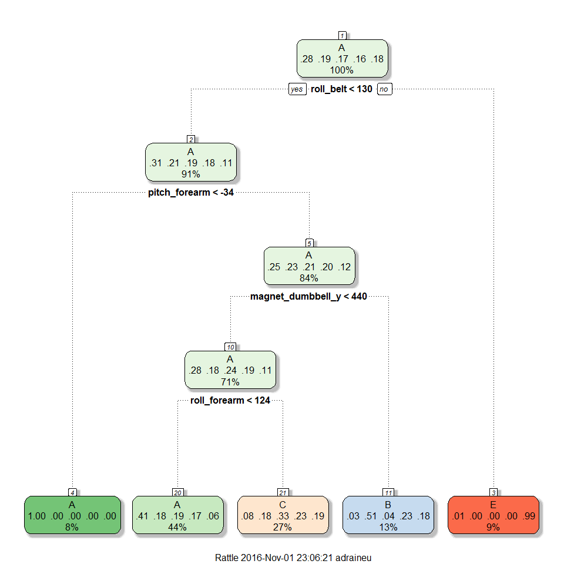

```r
fancyRpartPlot(model1$finalModel)
```

```r
#print(model1$finalModel)
predtree <- predict(model1,newdata =validation)
confusionMatrix(predtree,validation$classe)
```

```
## Confusion Matrix and Statistics
##
##           Reference
## Prediction    A    B    C    D    E
##          A 1284  392  388  380  141
##          B   21  331   23  126  137
##          C   88  226  444  298  236
##          D    0    0    0    0    0
##          E    2    0    0    0  387
##
## Overall Statistics
##
##                Accuracy : 0.499
##                  95% CI : (0.485, 0.513)
##     No Information Rate : 0.284
##     P-Value [Acc > NIR] : <2e-16
##
##                   Kappa : 0.344
##  Mcnemar's Test P-Value : NA
##
## Statistics by Class:
##
##                      Class: A Class: B Class: C Class: D Class: E
## Sensitivity             0.920   0.3488   0.5193    0.000   0.4295
## Specificity             0.629   0.9224   0.7906    1.000   0.9995
## Pos Pred Value          0.497   0.5188   0.3437      NaN   0.9949
## Neg Pred Value          0.952   0.8551   0.8862    0.836   0.8862
## Prevalence              0.284   0.1935   0.1743    0.164   0.1837
## Detection Rate          0.262   0.0675   0.0905    0.000   0.0789
## Detection Prevalence    0.527   0.1301   0.2635    0.000   0.0793
## Balanced Accuracy       0.775   0.6356   0.6549    0.500   0.7145
```

```r
##was model overfit?
tree <- predict(model1,newdata =training5)
confusionMatrix(tree,training5$classe)$overall
```

```
##       Accuracy          Kappa  AccuracyLower  AccuracyUpper   AccuracyNull
##              0              0              0              1              0
## AccuracyPValue  McnemarPValue
##              0            NaN
```

```r
###no, accuracy equal on training and validation
```

```r
#Random Forest
library(randomForest)
model2 <- randomForest(as.factor(classe) ~ ., data=training5)
order(varImp(model2), decreasing = T)
```

```
##  [1]  1  3 40 38  2 37 39 36 34 26 10 13 12 35 14 46 23 51  7 29 31 11 28
## [24] 33 24 48 50  4 20 49 25 15 27 41 21 47 18 22 17 44 30  8  9 42 16  6
## [47]  5 32 45 43 19
```

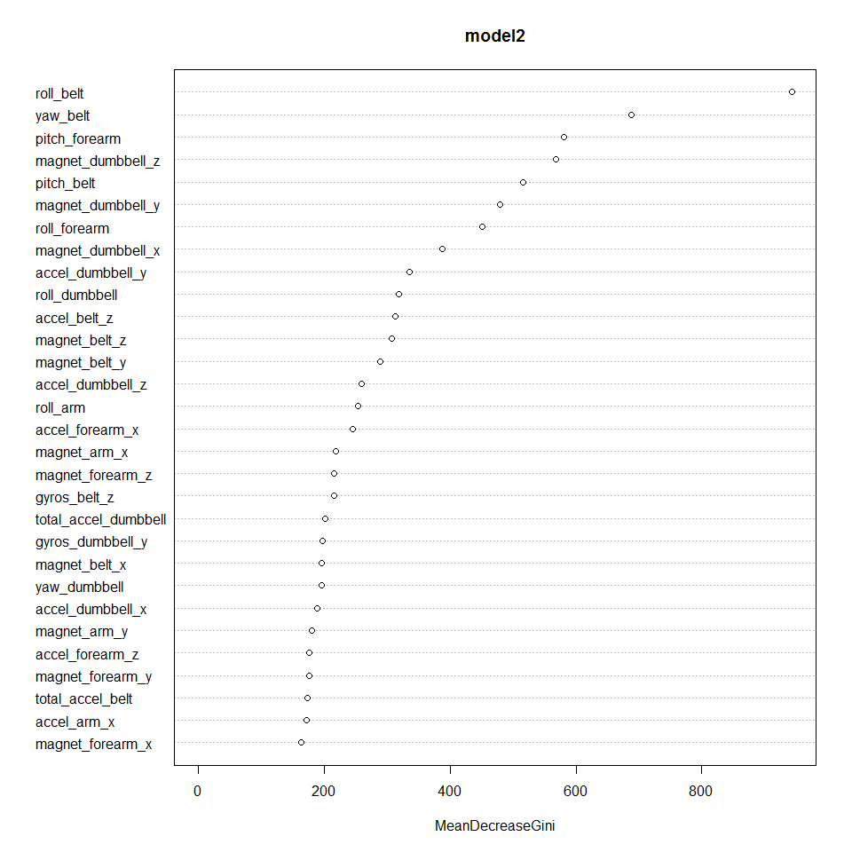

```r
varImpPlot(model2,type=2)
```

```r
##Reference:https://www.r-bloggers.com/variable-importance-plot-and-variable-selection/
predrf <- predict(model2,newdata =validation)
confusionMatrix(predrf,validation$classe)
```

```
## Confusion Matrix and Statistics
##
##           Reference
## Prediction    A    B    C    D    E
##          A 1395    4    0    0    0
##          B    0  944    5    0    0
##          C    0    1  850   10    0
##          D    0    0    0  794    1
##          E    0    0    0    0  900
##
## Overall Statistics
##
##                Accuracy : 0.996
##                  95% CI : (0.993, 0.997)
##     No Information Rate : 0.284
##     P-Value [Acc > NIR] : <2e-16
##
##                   Kappa : 0.995
##  Mcnemar's Test P-Value : NA
##
## Statistics by Class:
##
##                      Class: A Class: B Class: C Class: D Class: E
## Sensitivity             1.000    0.995    0.994    0.988    0.999
## Specificity             0.999    0.999    0.997    1.000    1.000
## Pos Pred Value          0.997    0.995    0.987    0.999    1.000
## Neg Pred Value          1.000    0.999    0.999    0.998    1.000
## Prevalence              0.284    0.194    0.174    0.164    0.184
## Detection Rate          0.284    0.192    0.173    0.162    0.184
## Detection Prevalence    0.285    0.194    0.176    0.162    0.184
## Balanced Accuracy       0.999    0.997    0.996    0.994    0.999
```

```r
confusionMatrix(predrf,validation$classe)$overall
```

```
##       Accuracy          Kappa  AccuracyLower  AccuracyUpper   AccuracyNull
##              1              1              1              1              0
## AccuracyPValue  McnemarPValue
##              0            NaN
```

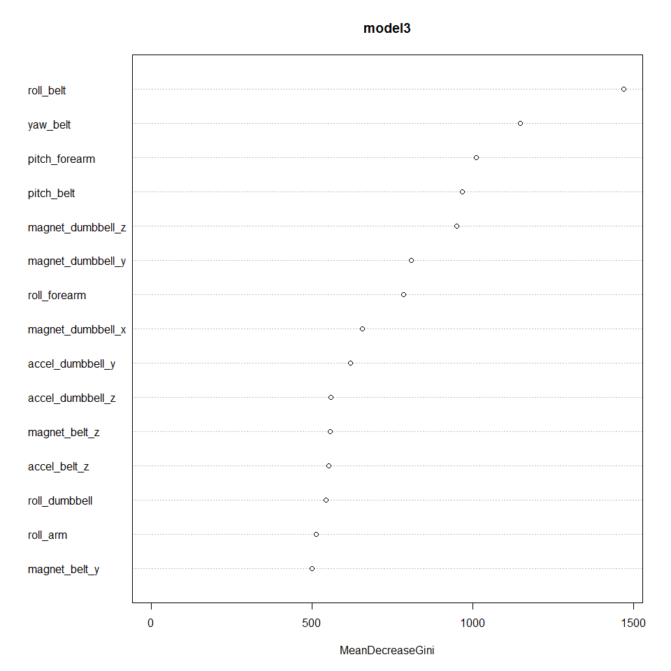

```r
##plot top 15 variables
importanceOrder=order(-model2$importance)
names=rownames(model2$importance)[importanceOrder][1:15]
#Random Forest on reduced number of variables
training6=subset(training5,select=c("classe",names))
model3 <- randomForest(classe~., data=training6)
varImpPlot(model3,type=2)
```

```r
predrf2 <- predict(model3,newdata =validation)
confusionMatrix(predrf2,validation$classe)$overall
```

```
##       Accuracy          Kappa  AccuracyLower  AccuracyUpper   AccuracyNull
##              1              1              1              1              0
## AccuracyPValue  McnemarPValue
##              0            NaN
```

```r
#Boosting - creating a smaller data frame to run procedure
inTrain2 = createDataPartition(training5$classe, p = .3)[[1]]
training7 = training5[ inTrain2,]
model4 <- train(classe~., data = training7, method = "gbm")
predgbm <- predict(model4,newdata =validation)
confusionMatrix(predgbm,validation$classe)$overall
```

```
##       Accuracy          Kappa  AccuracyLower  AccuracyUpper   AccuracyNull
##              1              1              1              1              0
## AccuracyPValue  McnemarPValue
##              0              0
```

## Results

The Random Forest Model has the largest accuracy=1; therefore it is chosen to predict the testing data set

```r
testing2=subset(testing,select=c(names))
Test_cases <- predict(model3,newdata =testing2)
data.frame(Test_cases)
```

```
##    Test_cases
## 1           B
## 2           A
## 3           B
## 4           A
## 5           A
## 6           E
## 7           D
## 8           B
## 9           A
## 10          A
## 11          B
## 12          C
## 13          B
## 14          A
## 15          E
## 16          E
## 17          A
## 18          B
## 19          B
## 20          B
```